# 141B - SQL

Benjamin Jewell

2023-05-19

Load Libraries & make Connection

```r
library(RSQLite)
library(DBI)
library(knitr)

db = dbConnect(SQLite(), "E:\\College\\UC Davis\\STA141B\\HW3\\stats.stackexchange.db")
```

**Data Exploration:**

Here we print out the schema of tables and their columns, since it’s different than the website schema.

```r
#list all tables for easy viewing
dbListTables(db)
```

```
##  [1] "BadgeClassMap"     "Badges"            "CloseReasonMap"
##  [4] "Comments"          "LinkTypeMap"       "PostHistory"
##  [7] "PostHistoryTypeId" "PostLinks"         "PostTypeIdMap"
## [10] "Posts"             "TagPosts"          "Users"
## [13] "VoteTypeMap"       "Votes"
```

```r
db_summary = as.data.frame(do.call(cbind, lapply(dbListTables(db), function(x) dbListFields(db, x)[1:22])))
colnames(db_summary) = dbListTables(db)
db_summary
```

```
##    BadgeClassMap   Badges CloseReasonMap        Comments LinkTypeMap
## 1             id       Id             id              Id          id
## 2          value   UserId          value          PostId       value
## 3           <NA>     Name           <NA>           Score        <NA>
## 4           <NA>     Date           <NA>            Text        <NA>
## 5           <NA>    Class           <NA>    CreationDate        <NA>
## 6           <NA> TagBased           <NA>          UserId        <NA>
## 7           <NA>     <NA>           <NA>  ContentLicense        <NA>
## 8           <NA>     <NA>           <NA> UserDisplayName        <NA>
## 9           <NA>     <NA>           <NA>            <NA>        <NA>
## 10          <NA>     <NA>           <NA>            <NA>        <NA>
## 11          <NA>     <NA>           <NA>            <NA>        <NA>
## 12          <NA>     <NA>           <NA>            <NA>        <NA>
## 13          <NA>     <NA>           <NA>            <NA>        <NA>
## 14          <NA>     <NA>           <NA>            <NA>        <NA>
```

[output cut: 54 more lines]

**General Note:** I will occasionally leave sections of commented code out here. These are highlighting the tables I used to “build up” to the final query I used.

Answered Questions: {1,2,3,4,5,8,9,10,11,12,14,15,16}(13/13)

**QUESTION 1:** How many users are there?

It was found that there are 321,677 users, by counting the number of Ids from the Users table.

```r
kable(dbGetQuery(db, 'SELECT COUNT(Id) FROM Users'), col.names = 'Number of users:')
```

| Number of users: |
| --- |
| 321677 |

**QUESTION 2:** How many users joined since 2020? (Hint: Convert the CreationDate to a year.)

We found that 100796 users have joined from after the first second of January 1st, 2020. This was found by counting the CreationDate from the Users table where their CreationDate was greater than the start of 2020.

```r
kable(dbGetQuery(db, 'SELECT COUNT(CreationDate) FROM Users WHERE JULIANDAY(CreationDate) > JULIANDAY("2020-01-01T00:00:01")'), col.names = "Number of users that have joined since the start of 2020")
```

| Number of users that have joined since the start of 2020 |
| --- |
| 100796 |

**QUESTION 3:** How many users joined each year? Describe this with a plot, commenting on any anomalies.

The CreationDate of each Users was selected and grouped by, counting how many joined each year. I calculated both the amount that joined each year and the cumulative sum so we can see the total number of users per year. It seems like the peak growth was in 2017 and has slowly been declining. I don’t know enough about the statistics/stackoverflow community to comment on why it’s slowly been going down other than to guess that as the product ages less people join. As for the large dip at the end however that is like explained because our table only has data up through March 5th of 2023, so it doesn’t have a full year’s worth of users joining. I imagine if you redid this with the data on December 31st this year there would be much less of a drastic decrease.

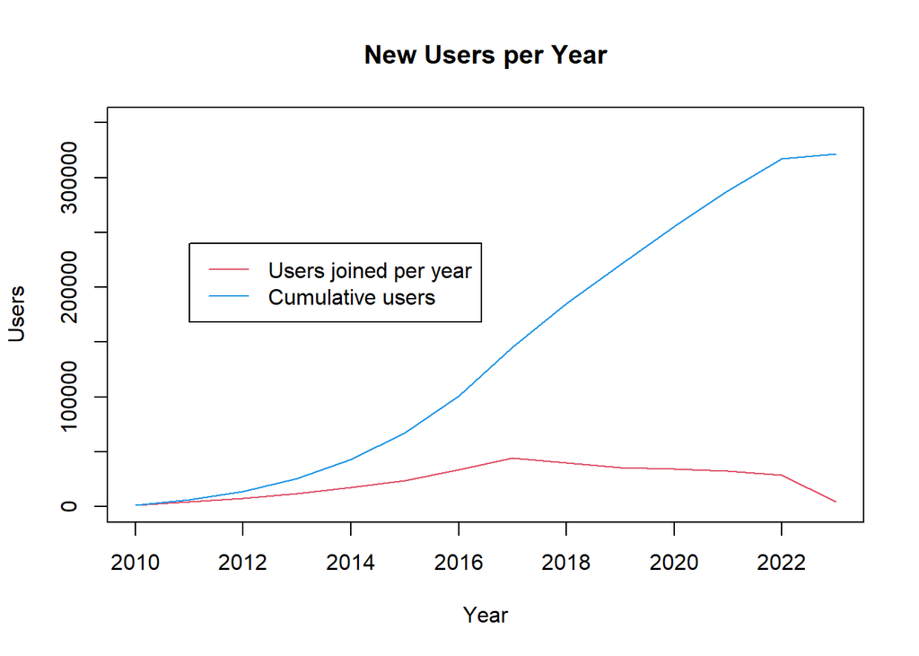

```r
join_df = dbGetQuery(db, 'SELECT strftime("%Y", CreationDate) AS yr, COUNT(*) AS yr_count FROM Users GROUP BY yr')

plot(join_df, type='l', xlab = 'Year', ylab = 'Users', main='New Users per Year', ylim = c(0,350000), col=2)
join_df[,"Cumulative Users"] = cumsum(join_df$yr_count) #[2] Cumsum new column
lines(join_df$yr, join_df$`Cumulative Users`, col=4)
legend(2011,240000, legend=c('Users joined per year', 'Cumulative users'), col=c(2,4), lty=c(1,1))
```

```r
kable(join_df, col.names = c('Year', 'New Users', 'Cumm. New Users'))
```

| Year | New Users | Cumm. New Users |
| --- | --- | --- |
| 2010 | 1668 | 1668 |
| 2011 | 4396 | 6064 |
| 2012 | 7450 | 13514 |
| 2013 | 11846 | 25360 |
| 2014 | 17809 | 43169 |
| 2015 | 24012 | 67181 |
| 2016 | 33753 | 100934 |
| 2017 | 44416 | 145350 |
| 2018 | 40040 | 185390 |
| 2019 | 35491 | 220881 |
| 2020 | 34617 | 255498 |
| 2021 | 32765 | 288263 |
| 2022 | 28801 | 317064 |
| 2023 | 4613 | 321677 |

**QUESTION 4:** How many different types of posts are there in the Posts table?

According to the PostTypeIdMap table there are 8 kinds of posts. However here where we sorted the posts by their PostTypeId and used COUNT to count them, only 7 of the 8 are present in this data. We used a join with PostTypeIdMap to print their appropriate types.

```r
kable(dbGetQuery(db, 'SELECT PostTypeID, COUNT(*) As Count, PostTypeIdMap.value FROM Posts INNER JOIN PostTypeIdMap ON Posts.PostTypeId = PostTypeIdMap.id GROUP BY PostTypeID'), col.names = c('Id', 'Count', 'Value'))
```

| Id | Count | Value |
| --- | --- | --- |
| 1 | 204370 | Question |
| 2 | 197928 | Answer |
| 3 | 6 | Orphaned tag wiki |
| 4 | 1444 | Tag wiki excerpt |
| 5 | 1444 | Tag wiki |
| 6 | 23 | Moderator nomination |
| 7 | 5 | Wiki placeholder (seems to only be the election description) |

**QUESTION 5:** How many posted questions are there?

There are 204,370 questions asked in our data. We counted all posts where the PostTypeId = 1, which indicates it’s a question and not something like an answer. Here we demonstrate that using PostTypeId = 1 mapped to the ‘Question’ Id from PostTypeIdMap gives the same results.

```r
#PostTypeId = 1 : Question Type
kable(dbGetQuery(db, 'SELECT COUNT(PostTypeID) FROM Posts WHERE PostTypeID = 1'), col.names = 'Number of Questions Asked')
```

| Number of Questions Asked |
| --- |
| 204370 |

```r
kable(dbGetQuery(db, 'SELECT COUNT(PostTypeID) FROM Posts WHERE PostTypeID IN (SELECT id FROM PostTypeIdMap WHERE value = "Question")'),
      col.names = 'Number of Questions Asked via PostTypeIdMap')
```

| Number of Questions Asked via PostTypeIdMap |
| --- |
| 204370 |

**QUESTION 8:** How many answers are there?

There are 197,928 answers in our data. We counted all posts where the PostTypeId = 2, which indicates it’s an answer and not something like a question.

```r
kable(dbGetQuery(db, 'SELECT COUNT(PostTypeID) FROM Posts WHERE PostTypeID = 2'), col.names = 'Number of Answers')
```

| Number of Answers |
| --- |
| 197928 |

```r
kable(dbGetQuery(db, 'SELECT COUNT(PostTypeID) FROM Posts WHERE PostTypeID IN (SELECT id FROM PostTypeIdMap WHERE value = "Answer")'), col.names = 'Number of Answers via PostTypeIdMap')
```

| Number of Answers via PostTypeIdMap |
| --- |
| 197928 |

```r
kable(dbGetQuery(db, 'SELECT SUM(AnswerCount) FROM Posts'), col.names = 'Verifying via Summing AnswerCount of all posts')
```

| Verifying via Summing AnswerCount of all posts |
| --- |
| 197928 |

**QUESTION 9**: What’s the most recent question (by date-time) in the Posts table?

URL: https://stats.stackexchange.com/questions/608405

ALT URL: https://stats.stackexchange.com/questions/608458/are-there-any-methods-that-combine-mcmc-and-vi

How would we map a question in posts table to it’s URL:

Normally we could append the Post ID to https://stats.stackexchange.com/questions/%7BId%7D but it seems like not all posts exist. For example, https://stats.stackexchange.com/questions/608405 doesn’t exist and actually exist. However using Google with the contents of the post I was able to find a post that matched half of the new post and decided that would be more useful to us. You can’t do much if the newest post just throws a 404 error at you.

To find this we found the largest CreationDate to find the newest post is at 5:10:18 AM on March 5th, 2023, with ID 608405. I wasn’t certain how to link them to the URL but figured there must be a way. In fact it turns out if you type in ‘https://stats.stackexchange.com/questions/’ and then append the Post Id it will take you to that post. While this works for a lot of the Question IDS, it doesn’t work for post 608405, as it just gives you a ‘404 Page not found’ error. However if you search Google using the text from the body you can find a post that occurs later after our data set, Post #608458 which matches half of the body of Post #608405. Ultimately together these two posts give you the newest post in our data set, with one answer sticking to the “letter of the law”, and another giving an answer that is more the “spirit of the law”.

```r
kable(dbGetQuery(db, 'SELECT MAX(CreationDate) FROM Posts'), col.names = 'Newest Post Time')
```

| Newest Post Time |
| --- |
| 2023-03-05T05:10:18.393 |

```r
kable(dbGetQuery(db, 'SELECT Id FROM Posts WHERE CreationDate = (SELECT MAX(CreationDate) FROM Posts)'), col.names = 'Newest Post ID')
```

| Newest Post ID |
| --- |
| 608405 |

```r
dbGetQuery(db, 'SELECT Body FROM Posts WHERE CreationDate = "2023-03-05T05:10:18.393"')[[1]]
```

```
## [1] "<p>Are there any methods that combine VI and MCMC? If it exists, why isn’t it used prominently over techniques such as NUTS or other VIs.</p>\\\\n<p>Another question that just popped up in my head why is HMC sampling parallelizable after stationary? Is it related with some kind of sequential…
```

**QUESTION 10:** Top 10 Questions Posted Users: How many questions did they post, usernames, when did they join, reputation, country?

For Username we use Users.DisplayName, for their join date we use Users.CreationDate, for their reputation we use Users.Reputation and for country we use Users.Location (not all people list a country, but many do. As there’s no Country value this seemed most appropriate.)

We make a table with the top 10 users and how many posts they make, using an Inner Join with the Users table to filter to only having the to 10 question posters.

```r
#Double Checking the way we select the number of posts per user is correct
ct = dbGetQuery(db, 'SELECT OwnerDisplayName, OwnerUserId, COUNT(*) FROM Posts GROUP BY OwnerUserId ')
#There are 405220 posts, and we have that many here!
sum(ct$`COUNT(*)`)
```

```
## [1] 405220
```

```r
#We ignore user28 since they have no ID so we can't look up any results on them
dbGetQuery(db, 'SELECT OwnerDisplayName, OwnerUserId, COUNT(*) FROM Posts WHERE OwnerUserId <>"" GROUP BY OwnerUserId ORDER BY COUNT(OwnerUserId) DESC LIMIT 10;')
```

```
##    OwnerDisplayName OwnerUserId COUNT(*)
## 1                           805     4850
## 2                           919     3152
## 3                           686     3080
## 4                         28500     2703
## 5                         11887     2638
## 6                         35989     2546
## 7                        173082     2297
## 8                          1352     2238
## 9                         85665     2190
## 10                         7290     1907
```

```r
#dbGetQuery(db, 'SELECT Id, DisplayName, CreationDate, Reputation, Location FROM Users WHERE Id IN (SELECT OwnerUserId FROM Posts WHERE OwnerUserId <>"" GROUP BY OwnerUserId ORDER BY COUNT(OwnerUserId) DESC LIMIT 10);')

kable(dbGetQuery(db, 'SELECT Id, DisplayName, CreationDate, Reputation, Location, Freq
                 FROM Users
                 INNER JOIN (SELECT OwnerUserId, COUNT(*) as Freq FROM Posts WHERE OwnerUserId <>"" GROUP BY OwnerUserId ORDER BY COUNT(OwnerUserId) DESC LIMIT 10) AS Table2 ON Table2.OwnerUserId = Users.Id
                 WHERE Id IN (SELECT OwnerUserId FROM Posts WHERE OwnerUserId <>"" GROUP BY OwnerUserId ORDER BY COUNT(OwnerUserId) DESC LIMIT 10);'),
      col.names = c('Id', 'Username', 'Join Date', 'Reputation', 'Location', 'Post Count'))
```

| Id | Username | Join Date | Reputation | Location | Post Count |
| --- | --- | --- | --- | --- | --- |
| 805 | Glen_b | 2010-08-07T08:40:07.287 | 268966 | I’m right here | 4850 |
| 919 | whuber | 2010-08-13T15:29:47.140 | 304878 |  | 3152 |
| 686 | Peter Flom | 2010-08-03T19:42:40.907 | 97091 | New York, NY | 3080 |
| 28500 | EdM | 2013-07-26T15:11:03.380 | 76431 |  | 2703 |
| 11887 | kjetil b halvorsen | 2012-06-09T22:52:37.473 | 70519 | Bolivia | 2638 |
| 35989 | Tim | 2013-12-10T21:19:06.223 | 126510 | Warsaw, Poland | 2546 |
| 173082 | Ben | 2017-08-10T03:27:26.793 | 108435 | Canberra, Australia | 2297 |
| 1352 | Stephan Kolassa | 2010-09-18T10:55:08.240 | 107905 | Switzerland | 2238 |
| 85665 | BruceET | 2015-08-11T17:22:01.590 | 53074 | San Francisco Bay Area | 2190 |
| 7290 | gung - Reinstate Monica | 2011-11-09T04:43:15.613 | 138999 | Kingdom of Zhao | 1907 |

**QUESTION 11:** Following from the previous questions, for the 10 users who posted the most questions, how many gold, silver and bronze badges does each of these 10 individuals have?

Here we made an Inner Join between Badges.UserId and the Id of the top 10 users, as we found them in the previous question. We group by their UserId and the Medal Classes to give our table, and use Count() to see how many of each they have.

```r
kable(dbGetQuery(db, 'SELECT UserId, Class, COUNT(*)
                FROM Badges
                 INNER JOIN (SELECT OwnerUserId, COUNT(*) as Freq FROM Posts WHERE OwnerUserId <>"" GROUP BY OwnerUserId ORDER BY COUNT(OwnerUserId) DESC LIMIT 10) AS tp10 ON Badges.UserId = tp10.OwnerUserId
                 GROUP BY UserID, Class'), col.names = c('User Id', 'Medal Class', 'Frequency'))
```

| User Id | Medal Class | Frequency |
| --- | --- | --- |
| 686 | 1 | 35 |
| 686 | 2 | 153 |
| 686 | 3 | 293 |
| 805 | 1 | 36 |
| 805 | 2 | 587 |
| 805 | 3 | 982 |
| 919 | 1 | 56 |
| 919 | 2 | 693 |
| 919 | 3 | 1193 |
| 1352 | 1 | 17 |
| 1352 | 2 | 215 |
| 1352 | 3 | 406 |
| 7290 | 1 | 85 |
| 7290 | 2 | 379 |
| 7290 | 3 | 676 |
| 11887 | 1 | 30 |
| 11887 | 2 | 160 |
| 11887 | 3 | 522 |
| 28500 | 1 | 9 |
| 28500 | 2 | 79 |
| 28500 | 3 | 230 |
| 35989 | 1 | 21 |
| 35989 | 2 | 240 |
| 35989 | 3 | 456 |
| 85665 | 1 | 2 |
| 85665 | 2 | 32 |
| 85665 | 3 | 88 |
| 173082 | 1 | 4 |
| 173082 | 2 | 193 |
| 173082 | 3 | 452 |

**QUESTION 12:** For each of the following terms, how many questions contain that term: Regression, ANOVA, Data Mining, Machine Learning, Deep Learning, Neural Network.

```r
#PostTypeId = 1 indicates that it is a question
kable(dbGetQuery(db, "SELECT COUNT(Body)
                 FROM Posts
                 WHERE (
                 (Body LIKE '%Regression%') OR (Body LIKE '%ANOVA%') OR (Body LIKE '%Data Mining%') OR (Body LIKE '%Machine Learning%') OR (Body LIKE '%Deep Learning%') OR (Body LIKE '% Neural Network%')
                 OR
                 (Title LIKE '%Regression%') OR (Title LIKE '%ANOVA%') OR (Title LIKE '%Data Mining%') OR (Title LIKE '%Machine Learning%') OR (Title LIKE '%Deep Learning%') OR (Title LIKE '% Neural Network%'))
                 AND Posts.PostTypeId = 1"),
      col.names = 'Number of Questions Containing the terms')
```

| Number of Questions Containing the terms |
| --- |
| 58567 |

**QUESTION 14:** What is the date range for the questions and answers in this database?

Here we use MIN and MAX to look at the oldest and newest questions in our database, filtering by PostTypeId as appropriate. Because we are using JULIANDAY to calculate this, our differences are given in Days.

```r
#Questions
kable(dbGetQuery(db, 'SELECT MAX(CreationDate) FROM Posts WHERE PostTypeId = 1'), col.names = 'Newest Question Time')
```

| Newest Question Time |
| --- |
| 2023-03-05T05:10:18.393 |

```r
kable(dbGetQuery(db, 'SELECT MIN(CreationDate) FROM Posts WHERE PostTypeId = 1'), col.names = 'Oldest Question Time')
```

| Oldest Question Time |
| --- |
| 2009-02-02T14:21:12.103 |

```r
#Answers
kable(dbGetQuery(db, 'SELECT MAX(CreationDate) FROM Posts WHERE PostTypeId = 2'), col.names = 'Newest Answer Time')
```

| Newest Answer Time |
| --- |
| 2023-03-05T04:48:34.853 |

```r
kable(dbGetQuery(db, 'SELECT MIN(CreationDate) FROM Posts WHERE PostTypeId = 1'), col.names = 'Oldest Answer Time')
```

| Oldest Answer Time |
| --- |
| 2009-02-02T14:21:12.103 |

```r
#Difference [1]
kable(dbGetQuery(db, 'SELECT JULIANDAY(MAX(CreationDate)) - JULIANDAY(MIN(CreationDate)) FROM Posts WHERE PostTypeId = 1'), col.names = 'Number of days between oldest and newest question')
```

| Number of days between oldest and newest question |
| --- |
| 5143.617 |

```r
kable(dbGetQuery(db, 'SELECT JULIANDAY(MAX(CreationDate)) - JULIANDAY(MIN(CreationDate)) FROM Posts WHERE PostTypeId = 2'), col.names = 'Number of days between oldest and newest answer')
```

| Number of days between oldest and newest answer |
| --- |
| 5143.6 |

**QUESTION 15:** What Question has the most comments associated with it? How many answers are there?

Here we look at the Post (#386853) with the MAX CommentCount associated with it. We do a small amount of fiddling in R to make our Answer Count display as 0 below rather than NA, as this post has no answer.

```r
q15 = dbGetQuery(db, 'SELECT Id, CommentCount, AnswerCount FROM Posts WHERE CommentCount = (SELECT MAX(CommentCount) FROM Posts)')
#Formatting:
if (q15[1,3] == ''){q15[1,3] = 0}
q15$AnswerCount = as.numeric(q15$AnswerCount)
kable(q15, col.names = c('Post Id', 'Comment Count', 'Answer Count'))
```

| Post Id | Comment Count | Answer Count |
| --- | --- | --- |
| 386853 | 66 | 0 |

**QUESTION 16:** How many comments are there across all posts? How many posts have a comment? What is the distribution of comments per question?

This graph looks like it is likely Poisson or Exponentially distributed. This makes sense as it’s more likely a post has a few comments then a huge amount of comments. We looked at the total CommentCount from the Posts table to find how many comments there are, making sure to filter out empty comments (aka no comments).

```r
kable(dbGetQuery(db, 'SELECT SUM(CommentCount) FROM Posts WHERE CommentCount IS NOT NULL'), col.names = 'Total Comments')
```

| Total Comments |
| --- |
| 768069 |

```r
kable(dbGetQuery(db, 'SELECT COUNT(PostId) FROM Comments'), col.names = 'Total Comments via Comment Table')
```

| Total Comments via Comment Table |
| --- |
| 768069 |

```r
kable(dbGetQuery(db, 'SELECT COUNT(CommentCount) FROM Posts WHERE CommentCount IS NOT NULL'), col.names = 'Total Posts with 1+ Comment(s)')
```

| Total Posts with 1+ Comment(s) |
| --- |
| 405220 |

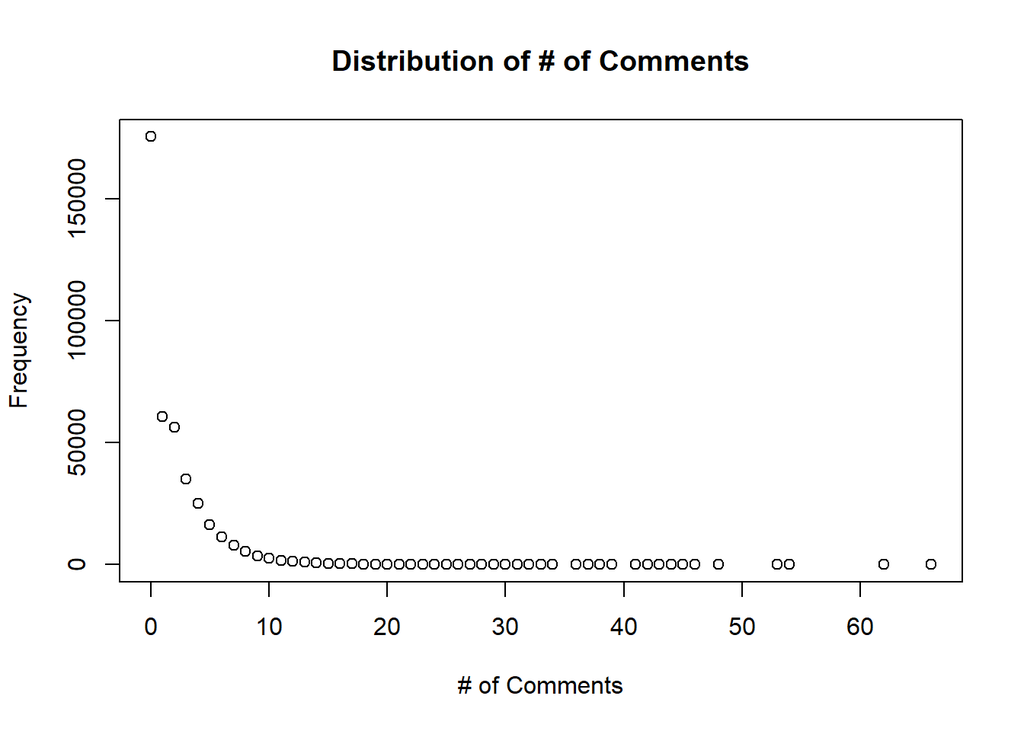

```r
plot(dbGetQuery(db, 'SELECT CommentCount, COUNT(CommentCount) FROM Posts WHERE CommentCount IS NOT NULL GROUP BY CommentCount'), xlab = '# of Comments', ylab= 'Frequency', main='Distribution of # of Comments')
```

=== **REQUIRE QUESTIONS** ===

**QUESTION 21:** Compute the table that contains: Question, Username of poster, when that user joined, their location, the date the question was first posted, accepted answer, when accepted answer was posted, name of the user who posted accepted answer

For this question we had to combine several variables together to create our table. Here is a summary of what I values I thought we’d need: - Posts.Title - OwnerDisplayName - Users.CreationDate - Users.Location - CreationDate - AcceptedAnswerId –> Posts.Body - AcceptedAnswerId –> CreationDate - AcceptedAnswerId –> OwnerDisplayName

NOTE: Due to the size of table I used head() here to limit the size and allow my computer to actually knit the file. The query will work without it though if you want to see the whole table!

```r
#Title, OwnerDisplayName, Users.CreationDate, Users.Location, CreationDate, AcceptedAnswerId-->Posts.Body, AcceptedAnswerId-->CreationDate, AcceptedAnswerId-->OwnerDisplayName

# dbGetQuery(db, 'SELECT p1.OwnerUserId, PUser.Id, p1.AcceptedAnswerId, ans.Id, ans.OwnerUserId, AUser.Id
#           FROM Posts as p1
#           INNER JOIN Users As PUser ON p1.OwnerUserId = PUser.Id
#           INNER JOIN Users AS AUser ON ans.OwnerUserId = AUser.Id
#           INNER JOIN Posts AS ans ON p1.AcceptedAnswerId = ans.Id
#           ')

head(dbGetQuery(db, 'SELECT p1.Title, PUser.DisplayName AS PosterUsername, PUser.CreationDate AS PosterJoinDate, PUser.Location AS PosterLocation, p1.CreationDate AS PostDate, ans.Body AS Answer, ans.CreationDate AS AnswerDate, AUser.DisplayName AS AnswerUsername
          FROM Posts as p1
          INNER JOIN Users As PUser ON p1.OwnerUserId = PUser.Id
          INNER JOIN Users AS AUser ON ans.OwnerUserId = AUser.Id
          INNER JOIN Posts AS ans ON p1.AcceptedAnswerId = ans.Id
          ORDER BY PostDate
          '))
```

```
##                                                               Title
## 1       What do you call an average that does not include outliers?
## 2                                     Eliciting priors from experts
## 3                                                What is normality?
## 4 What are some valuable Statistical Analysis open source projects?
## 5        Assessing the significance of differences in distributions
## 6                            Locating freely available data samples
##   PosterUsername          PosterJoinDate              PosterLocation
## 1         Tawani 2016-04-19T11:19:46.257
## 2    csgillespie 2010-07-19T19:04:52.280   Newcastle, United Kingdom
## 3         A Lion 2010-07-19T19:09:32.157
## 4         grokus 2010-07-19T19:08:29.070               United States
## 5    Jay Stevens 2010-07-19T19:09:16.917       Jacksonville, FL, USA
## 6         EAMann 2010-07-19T19:11:57.393 Tualatin, OR, United States
##                  PostDate
```

[output cut: 20 more lines]

**QUESTION 22:** Determine the users that have only posted questions and never answered a question? (Compute the table containing the number of questions, number of answers and the user’s login name for this group.) How many are there?

This question made me think I would need to compute a table of everyone who has posted a question. Then I would find the table of everyone who answered a question and drop everyone on the answer table from the questions table. The variables I saw as pertinent to this were: - OwnerUserId (Via GROUP BY OwnerUserId) - OwnerDisplayName - COUNT(Questions per User) - COUNT(Answers per User) <– If we did things right this should be NA or 0.

NOTE: Due to the size of table I used head() here to limit the size and allow my computer to actually knit the file. The query will work without it though if you want to see the whole table!

```r
# q22 = dbGetQuery(db, 'SELECT Users.Id, Users.DisplayName, COUNT(Posts.PostTypeId) AS AnswerCount
#            FROM Posts
#            INNER JOIN Users ON Posts.OwnerUserId = Users.Id
#            WHERE Posts.PostTypeId = 2
#            GROUP BY Users.Id')
#q22

# q22b = dbGetQuery(db, 'SELECT Users.Id, Users.DisplayName, COUNT(Posts.PostTypeId) AS QCount
#            FROM Posts
#            INNER JOIN Users ON Posts.OwnerUserId = Users.Id
#            WHERE Posts.PostTypeId = 1
#            GROUP BY Users.Id
#            ')
#q22b

#Test to make sure we are selecting overlapping Users
#intersect(q22$Id, q22b$Id)

q22c = dbGetQuery(db, 'SELECT QstC.Id, QstC.DisplayName, QstC.QCount AS QuestionsAnswered, AnsC.AnswerCount
                FROM (SELECT Users.Id, Users.DisplayName, COUNT(Posts.PostTypeId) AS AnswerCount
           FROM Posts
           INNER JOIN Users ON Posts.OwnerUserId = Users.Id
           WHERE Posts.PostTypeId = 2
           GROUP BY Users.Id) AS AnsC
                RIGHT JOIN (SELECT Users.Id, Users.DisplayName, COUNT(Posts.PostTypeId) AS QCount
           FROM Posts
           INNER JOIN Users ON Posts.OwnerUserId = Users.Id
           WHERE Posts.PostTypeId = 1
           GROUP BY Users.Id) AS QstC
                ON AnsC.Id = QstC.Id
            WHERE AnsC.AnswerCount IS NULL
            ORDER BY QstC.Id
                ')
head(q22c)
```

```
##   Id DisplayName QuestionsAnswered AnswerCount
## 1 18      grokus                 2          NA
## 2 24      A Lion                 2          NA
## 3 38      EAMann                 1          NA
## 4 52     Alan H.                13          NA
## 5 53        kyle                 2          NA
## 6 58      Preets                 1          NA
```

```r
#sum(q22c[which(is.na(q22c$AnswerCount)),])
```

**QUESTION 23:** Compute the table with information for the 75 users with the most accepted answers. This table should include: User display name, creation date, location, number of badges they have won (and names of badges), the dates of the earliest and most recent accepted answer (as two fields)(the unique tags for all questions for which they had the accepted answer (as a single string))

This was probably the table that took me the longest to understand how to group together. You can see multiple smaller tables I made below to try to figure out how to group the data. I decided to use Users as my “main” table, since a lot of the values seem to relate to that and we are finding the top 75 users. The hardest part for me was selecting the unique tags per user across questions they answered, as the DISTINCT value seems to apply to all selected columns. I’m sure there are more efficient ways to do this, but creating tables that acted as “keys” to INNER JOIN on made the most sense to me. As you can see by my notes, while some of these values seemed rather easy to calculate, others were much harder:

#DisplayName, CreationDate, Location, COUNT(Badges.UserId = Id), [???NAMES???], MIN(AcceptedAnswerId.OwnerUserId.CreationDate), MAX(AcceptedAnswerId.OwnerUserId.CreationDate), [???UNIQUE TAGS???]

For Names I ended up using GROUP_CONCAT to bring together all the badge names from a separate table I made of all the badges each user won.

For Unique Tags I had to use a similar strategy as Names but with the tags.

```r
#MAIN TABLE: Users
#DisplayName, CreationDate, Location, COUNT(Badges.UserId = Id), [???NAMES???], MIN(AcceptedAnswerId.OwnerUserId.CreationDate), MAX(AcceptedAnswerId.OwnerUserId.CreationDate), [???UNIQUE TAGS???]

#User 6:Harlan has 2 accepted answers via manual checking

kable(dbGetQuery(db, 'SELECT Users.Id, Users.DisplayName, Users.CreationDate, Users.Location, Badges.BadgesWon, Badges.BadgeList, Top75.EarliestAnswer, Top75.LatestAnswer, TT.UnqTags
           FROM Users
           INNER JOIN Posts AS p1 ON Users.Id = p1.OwnerUserId
           INNER JOIN Posts AS p2 ON p1.Id = p2.AcceptedAnswerId
           INNER JOIN (SELECT OwnerUserId, COUNT(*) AS Freq, MIN(CreationDate) AS EarliestAnswer, MAX(CreationDate) AS LatestAnswer
                FROM Posts
                WHERE Id IN (SELECT AcceptedAnswerId FROM Posts WHERE (NOT AcceptedAnswerId = "") OR (NOT AcceptedAnswerId IS NULL)) AND OwnerUserId <> ""
                GROUP BY OwnerUserId
                ORDER BY Freq DESC
                LIMIT 75
                ) AS Top75 ON Users.Id = Top75.OwnerUserId
          INNER JOIN (
                SELECT u.Id, COUNT(*) AS BadgesWon, GROUP_CONCAT(DISTINCT Badges.Name) AS BadgeList
                FROM Users AS u
                INNER JOIN Badges ON u.Id = Badges.UserId
                GROUP BY u.Id
                ) AS Badges ON Users.Id = Badges.Id
        LEFT JOIN (
                SELECT DISTINCT p.Id, t.Id, p.AcceptedAnswerId, a.Id, a.OwnerUserId, GROUP_CONCAT(DISTINCT t.Tag) AS UnqTags
                FROM Posts AS p
                INNER JOIN TagPosts AS t ON t.Id = p.Id
                INNER JOIN Posts AS a ON p.AcceptedAnswerId = a.Id
                WHERE p.AcceptedAnswerId <> ""
                GROUP BY a.OwnerUserId
                ) AS TT ON TT.OwnerUserId = Users.Id
        GROUP BY Users.Id
        ORDER BY Users.Id
'))
```

| Id | DisplayName | CreationDate | Location | BadgesWon | BadgeList | EarliestAnswer | LatestAnswer | UnqTags |
| --- | --- | --- | --- | --- | --- | --- | --- | --- |
| 159 | Rob Hyndman | 2010-07-19T23:05:39.653 | Melbourne, Australia | 346 | Autobiographer,Supporter,Organizer,Teacher,Student,Editor,Mortarboard,Scholar,Critic,Self-Learner,Commentator,Nice Answer,Cleanup,Beta,Nice Question,Good Answer,Enthusiast,Disciplined,Popular Question… | 2010-07-19T23:37:43.807 | 2022-12-08T21:17:24.037 | smoothing,kernel-smoothing,teaching,references,multivariate-analysis,outliers,distributions,random-variable,extreme-value,r,forecasting,rule-of-thumb,histogram,regression,data-visualization,multicolli… |
| 686 | Peter Flom | 2010-08-03T19:42:40.907 | New York, NY | 481 | Teacher,Supporter,Organizer,Student,Scholar,Quorum,Editor,Commentator,Nice Answer,Autobiographer,Necromancer,Yearling,Critic,Enthusiast,Good Answer,Nice Question,regression,Popular Question,Civic Duty… | 2010-12-28T15:30:54.830 | 2021-07-06T14:43:40.547 | logistic,self-study,regression,feature-selection,lasso,data-transformation,ancova,small-sample,excel,sas,marginal-distribution,discriminant-analysis,probit,ordered-logit,ordered-probit,data-visualizat… |
| 805 | Glen_b | 2010-08-07T08:40:07.287 | I’m right here | 1605 | Teacher,Editor,Supporter,Yearling,Commentator,Critic,Student,Scholar,Nice Answer,Analytical,Custodian,Excavator,Organizer,Enthusiast,Citizen Patrol,Tag Editor,Enlightened,Informed,Suffrage,Vox Populi,… | 2010-08-09T00:37:45.090 | 2023-02-23T22:11:02.110 | distributions,statistical-significance,normality-assumption,kolmogorov-smirnov-test,probability,games,dice,modeling,dataset,lognormal-distribution,normal-distribution,mean,generalized-linear-model,poi… |
| 887 | Dikran Marsupial | 2010-08-12T07:45:05.553 |  | 331 | Teacher,Supporter,Editor,Student,Commentator,Enthusiast,Critic,Nice Question,Self-Learner,Nice Answer,Necromancer,Enlightened,Popular Question,Yearling,machine-learning,Quorum,Revival,Good Question,cr… | 2010-08-16T09:07:50.237 | 2022-09-11T13:16:29.027 | machine-learning,svm,neural-networks,regression,logistic,lasso,classification,multivariate-analysis,distance-functions,markov-chain-montecarlo,optimization,monte-carlo,likelihood,p-value,references,ex… |
| 919 | whuber | 2010-08-13T15:29:47.140 |  | 1942 | Autobiographer,Teacher,Student,Supporter,Editor,Commentator,Organizer,Scholar,Enthusiast,Civic Duty,Tag Editor,Critic,Nice Answer,Mortarboard,Necromancer,Suffrage,Revival,Citizen Patrol,Talkative,Conv… | 2010-08-19T13:07:22.083 | 2023-03-05T00:12:24.030 | probability,intuition,r,time-series,hypothesis-testing,spss,entropy,forecasting,scoring-rules,point-process,cross-correlation,scale-invariance,confidence-interval,algorithms,beta-distribution,stationa… |
| 930 | chl | 2010-08-13T20:50:47.397 | Paris, France | 608 | Autobiographer,Student,Teacher,Supporter,Editor,Critic,Commentator,Organizer,Civic Duty,Citizen Patrol,Mortarboard,Nice Question,Promoter,Enthusiast,Scholar,Benefactor,Tag Editor,Investor,Self-Learner… | 2010-08-19T10:00:00.370 | 2020-11-20T19:50:00.997 | ordinal-data,likert,scales,measurement,hypothesis-testing,measurement-error,method-comparison,bland-altman-plot,categorical-data,data-transformation,continuous-data,structural-equation-modeling,data-v… |
| 1352 | Stephan Kolassa | 2010-09-18T10:55:08.240 | Switzerland | 638 | Student,Teacher,Supporter,Autobiographer,Editor,Scholar,Nice Answer,Commentator,Organizer,Enthusiast,Suffrage,Yearling,Popular Question,Good Answer,Analytical,Critic,Nice Question,Custodian,Discipline… | 2010-09-23T20:42:45.613 | 2023-03-02T07:47:57.410 | count-data,poisson-regression,regression,multicollinearity,r,econometrics,least-squares,constrained-regression,multiple-regression,neural-networks,time-series,estimation,arima,anova,dataset,poisson-di… |
| 1390 | Gavin Simpson | 2010-09-21T18:58:34.843 | Denmark | 296 | Editor,Teacher,Supporter,Nice Answer,Enlightened,Critic,Commentator,Enthusiast,Autobiographer,Organizer,Quorum,r,Student,Scholar,Talkative,Citizen Patrol,Promoter,Yearling,Necromancer,Mortarboard,Good… | 2010-09-24T15:36:42.200 | 2023-03-02T11:42:04.713 | r,biplot,correspondence-analysis,histogram,multivariate-analysis,terminology,distance-functions,regression,self-study,methodology,data-visualization,lme4-nlme,model-selection,aic,clustering,mgcv,rando… |
| 1934 | Wolfgang | 2010-11-09T18:15:27.370 | Netherlands | 132 | Student,Scholar,Nice Question,Supporter,Teacher,Nice Answer,Enlightened,Commentator,Editor,Critic,Enthusiast,Suffrage,Revival,Yearling,Caucus,Good Answer,Organizer,Citizen Patrol,Popular Question,Cust… | 2010-11-25T23:37:14.657 | 2022-11-09T13:14:16.193 | anova,mixed-model,effect-size,cohens-d,expected-value,exponential-distribution,gamma-distribution,distributions,r,repeated-measures,panel-data,regression,dataset,outliers,residuals,meta-analysis,genet… |
| 2116 | mpiktas | 2010-11-24T09:52:34.957 | Vilnius, Lithuania | 231 | Student,Editor,Scholar,Teacher,Supporter,Commentator,Revival,Nice Answer,Enthusiast,Organizer,Quorum,Enlightened,Disciplined,Civic Duty,Suffrage,Critic,Citizen Patrol,Tag Editor,Cleanup,Strunk & White… | 2010-12-08T10:22:15.833 | 2022-12-27T09:34:47.107 | r,bootstrap,heteroscedasticity,ggplot2,panel-data,generalized-moments,multilevel-analysis,regression,residuals,estimation,variance,expected-value,mixed-model,assumptions,standard-error,autocorrelation… |
| 2126 | Ben Bolker | 2010-11-24T20:42:46.860 | Hamilton, Canada | 248 | Teacher,Supporter,Nice Answer,Enlightened,Commentator,Editor,Yearling,Citizen Patrol,Critic,Caucus,Excavator,r,Necromancer,Organizer,Constituent,Civic Duty,Enthusiast,Good Answer,Custodian,Explainer,m… | 2010-12-11T20:40:51.063 | 2023-02-04T03:30:28.870 | distributions,probability,poisson-distribution,regression,interaction,r,bugs,jags,parameterization,modeling,negative-binomial-distribution,generalized-linear-model,count-data,residuals,highest-density… |
| 2958 | Henry | 2011-01-28T07:59:59.930 |  | 189 | Teacher,Editor,Supporter,Commentator,Enthusiast,Quorum,Revival,Student,Scholar,Fanatic,Nice Answer,Enlightened,Critic,Necromancer,Yearling,r,Caucus,Constituent,Organizer,Custodian,Pundit,probability,N… | 2011-02-01T00:44:41.830 | 2023-02-15T17:59:58.590 | probability,combinatorics,r,confidence-interval,binomial-distribution,proportion,dataset,hypothesis-testing,correlation,spearman-rho,survey,post-hoc,stratification,estimation,stochastic-processes,mult… |
| 3277 | ttnphns | 2011-02-16T19:33:34.657 | Moscow, Russia | 799 | Student,Teacher,Commentator,Editor,Organizer,Supporter,Scholar,Enthusiast,Critic,Nice Answer,Fanatic,Tag Editor,Enlightened,Yearling,Popular Question,pca,Custodian,Promoter,Strunk & White,Civic Duty,N… | 2011-07-08T07:13:43.410 | 2022-11-13T01:42:10.793 | r,factor-analysis,pca,discriminant-analysis,scatterplot,clustering,data-mining,python,distance-functions,anova,repeated-measures,manova,sphericity,regression,correlation,non-independent,multilevel-ana… |
| 3382 | IrishStat | 2011-02-23T13:29:56.240 | Warminster, PA, United States | 96 | Teacher,Autobiographer,Supporter,Editor,Revival,Commentator,Critic,Enthusiast,Necromancer,time-series,Yearling,Nice Answer,Tenacious,r,arima,forecasting,Enlightened,Explainer,Informed,Custodian,Caucus… | 2011-03-14T18:12:36.827 | 2022-04-23T18:41:27.197 | meta-analysis,experiment-design,effect-size,odds-ratio,relative-risk,time-series,hypothesis-testing,chow-test,change-point,statistical-significance,spss,r,chi-squared-test,arima,multiple-comparisons,c… |
| 4253 | Frank Harrell | 2011-04-20T12:59:07.093 | Nashville, TN | 511 | Teacher,Editor,Commentator,Supporter,Enthusiast,Revival,Nice Answer,Quorum,Critic,Good Answer,regression,Necromancer,Student,Yearling,Enlightened,Excavator,Promoter,r,Nice Question,Pundit,logistic,Gen… | 2011-04-20T13:03:50.337 | 2023-01-25T14:29:24.820 | epidemiology,roc,r,model-selection,predictive-models,ordinal-data,anova,maximum-likelihood,modeling,data-transformation,quantiles,interaction,survival,median,statistical-power,regression,regression-co… |
| 4505 | Greg Snow | 2011-05-07T13:44:25.593 | Utah | 261 | Teacher,Editor,Supporter,Nice Answer,Mortarboard,Commentator,Revival,Critic,Enthusiast,Organizer,Enlightened,r,Yearling,hypothesis-testing,regression,Necromancer,Custodian,Civic Duty,Good Answer,Gener… | 2011-05-10T19:45:10.343 | 2023-02-06T18:36:27.193 | p-value,uniform-distribution,teaching,validity,sample-size,kolmogorov-smirnov-test,regression,least-squares,error,r,mixed-model,multilevel-analysis,blocking,nonparametric,ties,distributions,variance,b… |
| 4598 | cbeleites unhappy with SX | 2011-05-13T10:02:56.203 | Germany | 218 | Editor,Teacher,Supporter,Commentator,Student,Citizen Patrol,Nice Answer,Enlightened,Quorum,Yearling,Critic,Self-Learner,Custodian,Organizer,Tumbleweed,Revival,Necromancer,Enthusiast,Tag Editor,Good An… | 2011-07-22T13:09:00.340 | 2023-01-15T20:11:53.877 | repeated-measures,multiple-comparisons,experiment-design,biostatistics,distributions,poisson-distribution,modeling,interpretation,multinomial-distribution,r,data-visualization,predictive-models,featur… |
| 5739 | StasK | 2011-08-08T17:31:44.413 | Columbia, MO | 255 | Autobiographer,Teacher,Commentator,Supporter,Organizer,Editor,Tag Editor,Nice Answer,Citizen Patrol,Announcer,Student,Scholar,Critic,Quorum,Booster,Mortarboard,Necromancer,Revival,Good Answer,Yearling… | 2011-08-08T21:29:26.753 | 2020-07-21T22:43:03.630 | confidence-interval,random-variable,bootstrap,random-generation,repeated-measures,trend,r,estimation,density-function,kernel-smoothing,auc,sampling,regression,time-series,nonlinear-regression,hidden-m… |
| 6193 | frank | 2011-09-06T14:28:52.203 |  | 48 | Scholar,Student,Popular Question,Custodian,Supporter,Notable Question,Famous Question,Caucus,Editor,Teacher,Yearling,Critic,Commentator,Nice Answer,Citizen Patrol,Tenacious,Enthusiast,Unsung Hero,Revi… | 2022-02-08T07:52:25.710 | 2022-12-02T15:28:09.620 | regression,machine-learning,classification,svm,probability,inference,hoeffdings-inequality,mean,median,population,curves,autoencoders,data-preprocessing,anomaly-detection,generalized-linear-model,gene… |
| 6633 | Dilip Sarwate | 2011-10-03T16:59:55.347 | Urbana, IL | 315 | Teacher,Editor,Supporter,Commentator,Citizen Patrol,Critic,Student,Scholar,Enthusiast,Quorum,Fanatic,Nice Answer,Enlightened,Necromancer,Excavator,Revival,Yearling,Custodian,Pundit,Good Answer,probabi… | 2011-10-04T12:03:25.833 | 2023-01-11T04:00:03.027 | probability,binomial-distribution,mean,maximum-likelihood,self-study,normal-distribution,sampling,moments,distributions,independence,exchangeability,approximation,probability-inequalities,expected-val… |
| 7071 | dimitriy | 2011-10-26T15:10:36.547 | Oakland, CA, USA | 225 | Student,Teacher,Scholar,Commentator,Editor,Supporter,Organizer,Critic,Promoter,Enthusiast,Tumbleweed,Quorum,Revival,Yearling,Citizen Patrol,Nice Answer,Enlightened,Custodian,Informed,Analytical,Civic … | 2012-01-25T20:03:37.290 | 2023-02-28T21:18:49.587 | regression,self-study,econometrics,time-series,autocorrelation,predictive-models,logistic,dataset,stata,text-mining,python,database,negative-binomial-distribution,linear-model,causality,hypothesis-tes… |
| 7224 | Xi’an | 2011-11-05T07:56:15.903 | Paris, France | 793 | Teacher,Editor,Supporter,Critic,Commentator,Analytical,Autobiographer,Organizer,Student,Announcer,Scholar,Nice Answer,Enlightened,Enthusiast,Disciplined,Tag Editor,Citizen Patrol,Civic Duty,Promoter,S… | 2011-11-05T21:11:34.147 | 2023-02-23T11:40:34.633 | bayesian,sampling,markov-chain-montecarlo,large-data,gibbs,logistic,stata,normal-distribution,bivariate,joint-distribution,independence,weighted-sampling,hypothesis-testing,graphical-model,binomial-di… |
| 7290 | gung - Reinstate Monica | 2011-11-09T04:43:15.613 | Kingdom of Zhao | 1140 | Editor,Scholar,Teacher,Supporter,Commentator,Analytical,Critic,Organizer,Enthusiast,Nice Answer,Enlightened,Quorum,Civic Duty,Fanatic,regression,Tag Editor,Revival,Student,Necromancer,Sportsmanship,Ex… | 2011-11-10T04:08:06.260 | 2023-03-02T22:01:38.573 | interpolation,splines,regression,correlation,multiple-regression,multivariate-regression,r,interpretation,standard-deviation,covariance,estimation,hypothesis-testing,statistical-significance,unbiased-… |
| 7486 | Robert Long | 2011-11-20T14:30:04.120 | Leeds, United Kingdom | 257 | Teacher,Student,Supporter,Editor,Scholar,Commentator,Citizen Patrol,Critic,Yearling,Promoter,Tumbleweed,Tag Editor,Organizer,Nice Question,Revival,Popular Question,Nice Answer,Curious,Autobiographer,E… | 2012-09-16T21:51:25.363 | 2021-10-24T18:45:04.263 | mixed-model,multilevel-analysis,random-effects-model,glmm,epidemiology,missing-data,propensity-scores,confidence-interval,r,lme4-nlme,statistical-power,maximum-likelihood,reml,multiple-imputation,mice… |
| 7555 | jbowman | 2011-11-23T02:34:06.680 | Berkeley, CA, USA | 189 | Teacher,Editor,Revival,Supporter,Commentator,Autobiographer,Nice Answer,Enlightened,Enthusiast,Organizer,Good Answer,Mortarboard,Critic,r,Civic Duty,Yearling,regression,Necromancer,Generalist,Custodia… | 2011-11-27T23:28:43.820 | 2023-02-25T18:00:47.460 | least-squares,multiple-regression,generalized-least-squares,bayesian,interpretation,prior,likelihood,posterior,spatial,bugs,r,sas,gamlss,variance,modeling,count-data,overdispersion,jags,time-series,re… |
| 7828 | Has QUIT–Anony-Mousse | 2011-12-06T08:56:19.207 | disappeared into oblivion | 174 | Supporter,Teacher,Editor,Organizer,Commentator,Autobiographer,Student,Revival,Nice Question,Tag Editor,Critic,Citizen Patrol,Tumbleweed,Scholar,Nice Answer,clustering,Excavator,Yearling,Popular Questi… | 2011-12-21T08:22:42.870 | 2019-12-18T22:35:37.650 | clustering,data-mining,machine-learning,references,distance,similarities,metric,r,time-series,dynamic-time-warping,online-algorithms,sas,outliers,data-imputation,multiple-imputation,ties,classificatio… |
| 7972 | Peter Ellis | 2011-12-13T02:20:43.653 | Melbourne, Australia | 136 | Teacher,Scholar,Autobiographer,Editor,Supporter,Organizer,Commentator,Critic,Analytical,Revival,Suffrage,Vox Populi,Nice Answer,Quorum,Student,Self-Learner,Enlightened,Excavator,Civic Duty,Promoter,Ni… | 2012-01-17T01:06:11.930 | 2018-02-03T00:14:07.023 | statistical-significance,chi-squared-test,r,poisson-distribution,lme4-nlme,correlation,survey,multilevel-analysis,bootstrap,resampling,out-of-sample,clustering,pca,probability,modeling,predictive-mode… |
| 8013 | AdamO | 2011-12-14T21:46:36.197 | Nakoja Abad | 343 | Teacher,Revival,Supporter,Editor,Student,Commentator,Critic,Analytical,Scholar,Yearling,Excavator,Organizer,Tumbleweed,Citizen Patrol,Nice Answer,Enthusiast,Quorum,Promoter,Necromancer,Custodian,Caucu… | 2011-12-15T00:35:15.920 | 2023-02-27T19:12:49.380 | chi-squared-test,p-value,independence,continuous-data,density-function,regression,sas,standard-error,linear-model,unbalanced-classes,sums-of-squares,terminology,epidemiology,confidence-interval,correl… |
| 8336 | Taylor | 2012-01-04T21:10:36.243 | Virginia, United States | 109 | Editor,Student,Teacher,Supporter,Analytical,Citizen Patrol,Commentator,Scholar,Promoter,Benefactor,Tumbleweed,Yearling,Autobiographer,Curious,Critic,Excavator,Explainer,Mortarboard,Organizer,Nice Answ… | 2012-03-29T21:08:02.050 | 2023-01-12T16:38:42.003 | self-study,mathematical-statistics,time-series,correlation,lags,regression,bayesian,prior,bayes,pivot,identifiability,estimability,probability,prediction,covariance,autocorrelation,stationarity,histog… |
| 9964 | Danica | 2012-03-19T19:49:40.507 | Vancouver, BC, Canada | 190 | Autobiographer,Critic,Teacher,Supporter,Yearling,Commentator,Editor,Citizen Patrol,Caucus,Announcer,Nice Answer,Revival,Necromancer,Informed,Explainer,Constituent,Custodian,Student,Organizer,Quorum,Mo… | 2013-05-21T02:10:09.063 | 2022-04-22T06:06:07.783 | density-function,unbiased-estimator,distance-functions,functional-data-analysis,hellinger,estimation,sampling,probability,mathematical-statistics,moments,moment-generating-function,multiple-regression… |
| 11032 | Michael R. Chernick | 2012-05-02T14:04:04.697 | Holland, Pennsylvania, United States | 254 | Teacher,Revival,Student,Mortarboard,Commentator,Editor,Supporter,Critic,Necromancer,Quorum,Vox Populi,Suffrage,Nice Answer,Civic Duty,Enthusiast,Scholar,Enlightened,Sportsmanship,Peer Pressure,Fanatic… | 2012-05-02T15:41:40.813 | 2019-01-18T01:47:56.287 | mixed-model,bootstrap,confidence-interval,monte-carlo,simulation,estimation,spatial,self-study,mathematical-statistics,distributions,histogram,mixture-distribution,bayesian,time-series,independence,de… |
| 11852 | usεr11852 | 2012-06-08T10:20:40.383 | Manchester, UK | 219 | Teacher,Supporter,Analytical,Editor,Necromancer,Critic,Cleanup,Commentator,Organizer,Suffrage,Enthusiast,Vox Populi,Informed,Civic Duty,Yearling,Nice Answer,Enlightened,Custodian,Revival,Quorum,Tag Ed… | 2012-08-22T01:47:05.583 | 2023-02-24T14:00:03.003 | pca,model-selection,probability,correlation,conditional-probability,random-generation,time-series,machine-learning,data-mining,panel-data,functional-data-analysis,gaussian-process,clustering,matlab,co… |
| 11887 | kjetil b halvorsen | 2012-06-09T22:52:37.473 | Bolivia | 712 | Teacher,Supporter,Critic,Commentator,Editor,Student,Enthusiast,Citizen Patrol,Revival,Suffrage,Yearling,Custodian,Organizer,Civic Duty,Tumbleweed,Quorum,Autobiographer,Explainer,Nice Answer,Enlightene… | 2012-06-26T18:14:28.970 | 2023-02-16T14:22:14.383 | references,experiment-design,mathematical-statistics,probability,spss,generalized-linear-model,binomial-distribution,bernoulli-distribution,bayesian,maximum-likelihood,likelihood,frequentist,philosoph… |
| 14076 | Kodiologist | 2012-09-13T23:44:42.007 | Mount Sinai Health System | 112 | Informed,Student,Scholar,Teacher,Supporter,Editor,Commentator,Yearling,Citizen Patrol,Caucus,Promoter,Benefactor,Explainer,Critic,Investor,Excavator,Altruist,Autobiographer,Nice Answer,Good Answer,Tal… | 2015-02-08T18:10:36.170 | 2020-01-14T14:22:49.630 | prior,hierarchical-bayesian,beta-distribution,hyperparameter,experiment-design,panel-data,machine-learning,terminology,statistical-learning,negative-binomial-distribution,bernoulli-process,regression,… |
| 17072 | Jeremy Miles | 2012-11-21T21:55:31.517 | Los Angeles, CA | 109 | Teacher,Supporter,Commentator,Editor,Student,Critic,Nice Question,Citizen Patrol,Scholar,Enthusiast,Excavator,Organizer,Informed,Caucus,Constituent,Civic Duty,Yearling,Taxonomist,Popular Question,Revi… | 2013-03-20T00:49:38.207 | 2023-01-25T11:47:22.057 | confidence-interval,chi-squared-test,odds-ratio,spss,nonparametric,association-measure,kruskal-wallis-test,regression,correlation,statistical-significance,covariance,anova,t-test,r,structural-equation… |
| 17230 | Scortchi - Reinstate Monica | 2012-11-27T12:24:58.070 | England | 360 | Editor,Teacher,Analytical,Supporter,Excavator,Commentator,Critic,Citizen Patrol,Suffrage,Organizer,Revival,Custodian,Tag Editor,Vox Populi,Strunk & White,Informed,Civic Duty,Cleanup,Enthusiast,Elector… | 2012-11-29T12:33:39.650 | 2022-04-10T17:49:14.653 | statistical-significance,modeling,regression,anova,interaction,multiple-regression,econometrics,bayesian,conditional-probability,time-series,forecasting,probability,confidence-interval,degrees-of-free… |
| 21054 | COOLSerdash | 2013-02-20T08:48:36.937 |  | 225 | Student,Editor,Teacher,Supporter,Informed,Scholar,Commentator,Critic,Analytical,Mortarboard,Suffrage,Custodian,Organizer,Nice Answer,Enlightened,Civic Duty,Excavator,Strunk & White,Enthusiast,Vox Popu… | 2013-04-14T14:03:15.153 | 2023-02-17T14:34:40.123 | self-study,mathematical-statistics,covariance,probability,bayesian,inference,prior,r,p-value,arma,econometrics,classification,agreement-statistics,confidence-interval,binomial-distribution,linear-mode… |
| 22047 | Nick Cox | 2013-03-15T13:57:54.467 | Durham, UK | 296 | Teacher,Supporter,Critic,Editor,Commentator,Citizen Patrol,Enthusiast,Organizer,Informed,Nice Answer,Enlightened,Excavator,Custodian,Strunk & White,Tenacious,Pundit,Mortarboard,Copy Editor,regression,… | 2013-03-22T02:41:59.837 | 2023-02-08T22:44:47.703 | factor-analysis,stata,data-visualization,categorical-data,ordinal-data,scatterplot,python,negative-binomial-distribution,descriptive-statistics,regression,generalized-linear-model,data-transformation,… |
| 22311 | Sycorax | 2013-03-20T23:59:56.610 | Washington, DC, United States | 565 | Student,Editor,Autobiographer,Scholar,Supporter,Teacher,Commentator,Critic,Citizen Patrol,Informed,Organizer,Excavator,Caucus,Constituent,Promoter,Tag Editor,Strunk & White,Civic Duty,Enthusiast,Yearl… | 2013-03-24T21:49:36.957 | 2023-02-22T13:47:21.993 | normal-distribution,matrix-decomposition,maximum-likelihood,bayesian,prior,conjugate-prior,hypothesis-testing,z-test,distributions,data-transformation,logistic,experiment-design,case-control-study,gwa… |
| 23853 | Maarten Buis | 2013-04-03T10:24:26.900 | Konstanz, Germany | 92 | Informed,Teacher,Editor,Autobiographer,Supporter,Custodian,Commentator,Citizen Patrol,Critic,Revival,Mortarboard,Organizer,Caucus,Constituent,Nice Answer,Yearling,Explainer,Enlightened,Enthusiast,Necr… | 2013-04-05T09:19:30.130 | 2022-09-28T08:37:38.007 | generalized-linear-model,logit,link-function,logistic,categorical-data,ordinal-data,feature-engineering,covariance,matrix,covariance-matrix,regression,mixture-distribution,r,interaction,interpretation… |
| 25433 | Marc Claesen | 2013-05-09T09:38:54.573 | Belgium | 126 | Editor,Teacher,Autobiographer,Supporter,Informed,Custodian,Citizen Patrol,Critic,Commentator,Enthusiast,Student,Promoter,Benefactor,Scholar,Revival,Nice Answer,Caucus,Fanatic,Investor,Civic Duty,Tenac… | 2013-05-19T21:59:35.793 | 2016-08-05T07:58:57.917 | svm,matlab,libsvm,machine-learning,classification,clustering,r,eigenvalues,c++,kernel-trick,proof,logistic,roc,model-evaluation,mathematical-statistics,data-mining,large-data,regression,time-series,pr… |
| 26338 | Andy | 2013-05-31T11:45:45.470 |  | 199 | Scholar,Student,Teacher,Supporter,Informed,Promoter,Editor,Benefactor,Commentator,Enthusiast,Suffrage,Vox Populi,Civic Duty,Citizen Patrol,Organizer,Critic,Autobiographer,Quorum,Custodian,Revival,Exca… | 2013-06-24T20:39:06.227 | 2018-05-28T22:00:19.767 | clustering,standard-error,panel-data,logistic,categorical-data,stata,fixed-effects-model,random-effects-model,causality,mixed-model,mean,notation,covariance-matrix,hausman,hypothesis-testing,t-test,bo… |
| 26948 | shimao | 2013-06-16T15:24:48.493 |  | 142 | Tumbleweed,Editor,Teacher,Student,Scholar,Yearling,Citizen Patrol,Supporter,Commentator,Critic,Nice Answer,Mortarboard,Good Answer,Autobiographer,Enthusiast,Tenacious,Custodian,Revival,machine-learnin… | 2017-03-11T23:51:05.680 | 2022-06-12T16:16:08.920 | machine-learning,gradient-descent,reinforcement-learning,neural-networks,optimization,adam,bayesian,marginal-distribution,dirac-delta,conv-neural-network,recommender-system,supervised-learning,matrix-… |
| 28500 | EdM | 2013-07-26T15:11:03.380 |  | 318 | Teacher,Supporter,Informed,Commentator,Yearling,Revival,Editor,Organizer,Nice Answer,Enlightened,Tenacious,Caucus,Custodian,Unsung Hero,Explainer,Enthusiast,Civic Duty,Cleanup,Fanatic,regression,Citiz… | 2013-08-13T20:01:37.963 | 2023-03-02T21:10:15.797 | regression,hypothesis-testing,anova,unbalanced-classes,sums-of-squares,chi-squared-test,bias,r,statistical-significance,binomial-distribution,bayesian,bootstrap,survival,goodness-of-fit,cox-model,samp… |
| 28666 | amoeba | 2013-07-31T11:19:00.203 | St. Petersburg ⇨ Freiburg ⇨ London ⇨ Lisboa ⇨ Tübingen | 652 | Editor,Student,Scholar,Commentator,Informed,Teacher,Supporter,Custodian,Organizer,Nice Question,Citizen Patrol,Quorum,Critic,Excavator,Enthusiast,Revival,Civic Duty,Self-Learner,Curious,Yearling,Necro… | 2013-07-31T14:19:32.060 | 2019-04-12T22:30:19.857 | r,spss,pca,factor-analysis,factor-rotation,intuition,eigenvalues,faq,least-squares,deming-regression,total-least-squares,anova,linear-model,statistical-significance,t-test,p-value,effect-size,optimiza… |
| 28746 | Alecos Papadopoulos | 2013-08-02T14:24:21.923 |  | 398 | Teacher,Editor,Supporter,Commentator,Student,Enthusiast,Citizen Patrol,Caucus,Constituent,Quorum,Nice Answer,Enlightened,Talkative,Fanatic,Tenacious,Custodian,Organizer,Tag Editor,Revival,regression,M… | 2013-08-06T23:18:34.317 | 2023-02-17T22:16:49.770 | estimation,least-squares,robust,irls,normal-distribution,gamma-distribution,probability,maximum-likelihood,optimization,distributions,moment-generating-function,cumulants,regression,variance,instrumen… |
| 30005 | jld | 2013-09-06T18:51:41.153 | United States | 124 | Editor,Student,Scholar,Teacher,Supporter,Critic,Caucus,Yearling,Constituent,Autobiographer,Commentator,Enthusiast,Nice Answer,Enlightened,Civic Duty,Informed,Good Answer,Custodian,Guru,Citizen Patrol,… | 2014-06-23T18:53:12.960 | 2022-02-17T17:43:33.990 | svm,e1071,r,regression,generalized-linear-model,maximum-likelihood,logistic,multiple-regression,irls,self-study,poisson-distribution,umvue,categorical-data,binomial-distribution,multiple-comparisons,t… |
| 31978 | Greenparker | 2013-10-28T02:13:22.950 | Kanpur, Uttar Pradesh, India | 127 | Student,Teacher,Tumbleweed,Editor,Supporter,Commentator,Yearling,Critic,Organizer,Custodian,Explainer,Scholar,Curious,Informed,Autobiographer,Citizen Patrol,Investor,Nice Answer,Excavator,Enthusiast,S… | 2013-11-16T21:11:29.867 | 2019-12-20T20:28:10.490 | references,markov-chain-montecarlo,markov-process,bayes,decision-theory,point-estimation,self-study,bayesian,matlab,vector-autoregression,monte-carlo,posterior,rejection-sampling,regression,time-serie… |
| 35989 | Tim | 2013-12-10T21:19:06.223 | Warsaw, Poland | 717 | Editor,Autobiographer,Supporter,Teacher,Custodian,Student,Scholar,Excavator,Commentator,Citizen Patrol,Critic,Explainer,Revival,Nice Answer,Tumbleweed,Quorum,Informed,Yearling,Enlightened,Curious,Enth… | 2014-10-31T11:05:38.017 | 2023-02-25T07:53:52.917 | time-series,bernoulli-distribution,change-point,random-generation,stata,bootstrap,multilevel-analysis,resampling,frailty,bayesian,model-selection,posterior,mse,rms,mixed-model,random-effects-model,fix… |
| 36041 | Aksakal | 2013-12-11T15:34:17.843 | VA, United States | 286 | Editor,Teacher,Commentator,Critic,Supporter,Revival,Student,Enthusiast,Organizer,Tenacious,Custodian,Nice Answer,Enlightened,Yearling,Necromancer,Explainer,Quorum,Unsung Hero,Nice Question,Citizen Pat… | 2014-02-26T15:16:38.457 | 2023-02-10T17:33:22.003 | time-series,unit-root,structural-change,r,trend,logistic,multivariate-analysis,data-visualization,references,missing-data,bias,correlation,categorical-data,continuous-data,kernel-smoothing,cohens-kapp… |
| 44269 | Alexis | 2014-04-22T15:44:33.497 |  | 240 | Teacher,Editor,Revival,Necromancer,Student,Critic,Supporter,Commentator,Informed,Excavator,Custodian,Scholar,Promoter,Tag Editor,Organizer,Citizen Patrol,Benefactor,Enthusiast,Curious,Nice Answer,Self… | 2014-04-23T18:00:43.053 | 2023-02-01T17:32:31.337 | survival,dataset,poisson-distribution,teaching,hypothesis-testing,equivalence,tost,pca,factor-analysis,permutation-test,parallel-analysis,repeated-measures,t-test,nonparametric,distributions,wilcoxon-… |
| 52554 | Russ Lenth | 2014-07-22T15:40:09.550 | Iowa City, IA, USA | 83 | Student,Editor,Teacher,Informed,Supporter,Commentator,Revival,Critic,Quorum,Custodian,Promoter,Nice Question,Scholar,Necromancer,Benefactor,Self-Learner,Enthusiast,Citizen Patrol,Mortarboard,Organizer… | 2014-07-23T20:19:03.463 | 2023-02-22T03:41:50.710 | hypothesis-testing,anova,statistical-significance,t-test,multiple-comparisons,r,inference,regression,time-series,nonlinear-regression,seasonality,heteroscedasticity,error,assumptions,ancova,random-var… |
| 53690 | Richard Hardy | 2014-08-08T10:57:13.613 | Europe | 363 | Student,Scholar,Editor,Commentator,Supporter,Excavator,Teacher,Revival,Autobiographer,Curious,Informed,Tumbleweed,Enthusiast,Organizer,Nice Answer,Enlightened,Fanatic,Quorum,Explainer,Caucus,Constitue… | 2014-10-19T11:52:22.160 | 2023-03-02T17:22:20.020 | r,estimation,arima,garch,stationarity,cointegration,volatility-forecasting,time-series,t-test,multivariate-analysis,data-transformation,references,multiple-regression,vector-autoregression,econometric… |
| 60261 | Achim Zeileis | 2014-11-08T08:45:50.373 | Innsbruck, Austria | 96 | Teacher,Editor,Supporter,Caucus,Commentator,Constituent,Revival,Enthusiast,Citizen Patrol,Autobiographer,Critic,Informed,Explainer,Fanatic,Custodian,Yearling,Nice Answer,Enlightened,Organizer,Tag Edit… | 2014-12-11T09:15:31.540 | 2023-01-06T08:48:25.507 | poisson-distribution,negative-binomial-distribution,likelihood-ratio,random-forest,cart,r,statistical-significance,generalized-linear-model,binomial-distribution,beta-regression,rpart,offset,logistic,… |
| 60613 | Firebug | 2014-11-13T14:13:15.340 | Switzerland | 210 | Editor,Tumbleweed,Scholar,Student,Supporter,Citizen Patrol,Teacher,Informed,Autobiographer,Revival,Critic,Suffrage,Vox Populi,Yearling,Commentator,Enthusiast,Explainer,Civic Duty,Custodian,Disciplined… | 2015-05-02T13:38:19.193 | 2023-02-11T14:15:42.127 | machine-learning,svm,regularization,multiple-regression,standardization,classification,k-nearest-neighbour,unbalanced-classes,dimensionality-reduction,svd,high-dimensional,regression,error,accuracy,lo… |
| 67799 | Christoph Hanck | 2015-01-30T09:08:44.590 | Essen | 185 | Teacher,Editor,Supporter,Student,Revival,Autobiographer,Scholar,Informed,Commentator,Explainer,Necromancer,Promoter,Excavator,Critic,Organizer,Benefactor,Caucus,Custodian,Citizen Patrol,Constituent,Su… | 2015-02-18T13:39:17.883 | 2023-03-01T13:07:38.477 | bayesian,frequentist,r,regression,time-series,vector-autoregression,random-effects-model,panel-data,plm,self-study,stationarity,arma,stochastic-processes,cointegration,multiple-regression,generalized-… |
| 74500 | Matthew Drury | 2015-04-24T22:41:05.543 | Seattle, WA | 244 | Student,Editor,Teacher,Supporter,Commentator,Nice Answer,Custodian,Explainer,Informed,Enlightened,Enthusiast,Critic,Autobiographer,Good Answer,Civic Duty,Fanatic,Mortarboard,Talkative,Organizer,Reviva… | 2015-05-03T05:25:13.417 | 2020-10-19T18:45:52.417 | regression,correlation,least-squares,generalized-least-squares,machine-learning,classification,cart,boosting,interpretation,regression-coefficients,lasso,generalized-additive-model,splines,mean,median… |
| 85665 | BruceET | 2015-08-11T17:22:01.590 | San Francisco Bay Area | 122 | Autobiographer,Teacher,Editor,Revival,Supporter,Commentator,Caucus,Yearling,Critic,Explainer,Citizen Patrol,Nice Answer,Informed,Enthusiast,Custodian,Organizer,Enlightened,Fanatic,Necromancer,Civic Du… | 2016-10-04T05:59:47.963 | 2022-07-02T05:16:55.040 | statistical-significance,self-study,estimation,maximum-likelihood,inference,variance,poisson-distribution,regression,outliers,leverage,goodness-of-fit,fitting,gamma-distribution,lognormal-distribution… |
| 86652 | Björn | 2015-08-23T14:39:03.497 | Europe | 109 | Informed,Student,Teacher,Supporter,Revival,Autobiographer,Commentator,Critic,Editor,Nice Answer,Enlightened,Enthusiast,Scholar,Custodian,Fanatic,Citizen Patrol,Civic Duty,Yearling,Promoter,Benefactor,… | 2015-08-24T19:13:07.693 | 2023-03-02T20:06:45.603 | machine-learning,bayesian,estimation,regression,data-imputation,multiple-imputation,stepwise-regression,mice,r,cox-model,kaplan-meier,time-varying-covariate,extrapolation,statistical-significance,simu… |
| 97925 | Matthew Gunn | 2015-12-11T19:40:42.483 |  | 141 | Teacher,Editor,Supporter,Critic,Commentator,Nice Answer,Mortarboard,Informed,Good Answer,Enthusiast,Autobiographer,Quorum,Organizer,Custodian,Civic Duty,Excavator,Disciplined,Enlightened,Pundit,Reviva… | 2015-12-11T08:30:43.697 | 2023-02-23T16:10:06.643 | regression,least-squares,linear-algebra,correlation,covariance,conditional-probability,notation,distributions,multiple-regression,linear-model,multivariate-normal-distribution,extreme-value,winsorizin… |
| 101426 | mdewey | 2016-01-21T14:04:37.277 | United Kingdom | 114 | Informed,Teacher,Autobiographer,Commentator,Editor,Citizen Patrol,Tenacious,Enthusiast,Supporter,Custodian,Critic,Fanatic,Organizer,Unsung Hero,Excavator,Quorum,Explainer,Revival,Proofreader,Tag Edito… | 2016-01-21T14:19:02.217 | 2023-02-08T12:05:02.193 | meta-analysis,network-meta-analysis,p-value,references,combining-p-values,hypothesis-testing,r,stepwise-regression,multivariate-analysis,meta-regression,categorical-data,chi-squared-test,odds-ratio,st… |
| 111259 | Demetri Pananos | 2016-04-06T21:32:38.250 | Toronto, ON, Canada | 162 | Autobiographer,Student,Editor,Supporter,Tumbleweed,Scholar,Commentator,Critic,Curious,Informed,Nice Question,Yearling,Custodian,Popular Question,Teacher,Nice Answer,Enlightened,Citizen Patrol,Enthusia… | 2018-11-11T21:12:41.223 | 2023-02-23T03:49:44.907 | time-series,statistical-significance,group-differences,machine-learning,nonparametric,prediction,proportion,r,regression,hypothesis-testing,likelihood-ratio,anova,paired-data,correlation,normal-distri… |
| 113777 | Haitao Du | 2016-04-27T20:51:38.203 |  | 377 | Teacher,Revival,Editor,Supporter,Informed,Critic,Commentator,Autobiographer,Custodian,Student,Nice Question,Promoter,Scholar,Enthusiast,Citizen Patrol,Quorum,Popular Question,Excavator,Curious,Discipl… | 2016-04-27T20:57:46.047 | 2021-11-14T13:52:20.913 | machine-learning,data-mining,predictive-models,boosting,overfitting,r,regression,gradient-descent,probability,markov-process,matrix,transition-matrix,prediction,standardization,linear,intuition,bayesi… |
| 115634 | Isabella Ghement | 2013-12-12T06:44:52.040 | Richmond, BC, Canada | 89 | Editor,Teacher,Enthusiast,Fanatic,Autobiographer,Popular Question,Scholar,Student,Supporter,Custodian,Nice Answer,Good Answer,Civic Duty,Commentator,Yearling,Revival,Explainer,Electorate,Curious,Criti… | 2018-03-18T22:15:08.510 | 2021-04-15T02:34:15.507 | experiment-design,regression,multiple-regression,linear-model,modeling,terminology,model,model-comparison,hypothesis-testing,data-transformation,ordinal-data,generative-models,r,interaction,statistica… |
| 116195 | Noah | 2016-05-19T15:46:14.703 | Cambridge, MA, United States | 109 | Teacher,Student,Editor,Organizer,Supporter,Citizen Patrol,Commentator,Critic,Tumbleweed,Scholar,Tenacious,Yearling,Autobiographer,Unsung Hero,Custodian,Revival,Curious,Necromancer,Nice Answer,Excavato… | 2016-07-01T23:26:52.873 | 2023-02-16T22:33:43.547 | interaction,causality,epidemiology,mediation,confounding,r,multiple-imputation,propensity-scores,predictor,matching,stratification,regression,mixed-model,linear-model,statistical-significance,small-sa… |
| 116440 | user20160 | 2016-05-22T03:26:26.563 |  | 178 | Teacher,Supporter,Revival,Editor,Informed,Student,Commentator,Citizen Patrol,Nice Answer,Custodian,Organizer,Critic,Tenacious,Tag Editor,Explainer,Enthusiast,machine-learning,Scholar,Necromancer,Popul… | 2016-05-22T03:39:12.343 | 2022-03-07T16:29:40.450 | cross-validation,neural-networks,probability,clustering,machine-learning,data-transformation,feature-engineering,signal-processing,fourier-transform,optimization,lasso,gradient-descent,model-selection… |
| 158565 | user158565 | 2017-04-24T04:49:47.677 |  | 31 | Teacher,Editor,Informed,Commentator,Critic,Nice Answer,Enthusiast,Supporter,Tenacious,Autobiographer,Unsung Hero,Yearling,Explainer,Custodian,Quorum,Citizen Patrol,Reviewer,Steward,Enlightened | 2017-04-24T07:03:17.630 | 2019-08-12T14:13:19.590 | self-study,expected-value,poisson-distribution,poisson-regression,link-function,offset,r,time-series,autocorrelation,autoregressive,generalized-least-squares,sampling,inference,regression,multiple-reg… |
| 164061 | Sextus Empiricus | 2017-06-05T10:39:01.763 | Sion, Switzerland | 298 | Autobiographer,Editor,Teacher,Supporter,Informed,Commentator,Critic,Revival,Enthusiast,Citizen Patrol,Caucus,Constituent,Custodian,Explainer,Nice Answer,Necromancer,Organizer,Student,Quorum,Excavator,… | 2017-06-07T21:08:17.853 | 2023-03-03T13:53:54.643 | hypothesis-testing,p-value,history,r,maximum-likelihood,nonlinear-regression,regression,goodness-of-fit,ordered-logit,rms,circular-statistics,multicollinearity,lm,ronald-fisher,linear-model,least-squa… |
| 166526 | Sal Mangiafico | 2017-06-24T13:11:05.510 | Greenwich, NJ 08323, United States | 49 | Teacher,Autobiographer,Supporter,Commentator,Editor,Enthusiast,Caucus,Tumbleweed,Critic,Constituent,Scholar,Student,Tenacious,Fanatic,Custodian,Informed,Unsung Hero,Revival,Yearling,Citizen Patrol,Civ… | 2017-06-24T13:40:10.947 | 2023-02-21T16:24:45.147 | chi-squared-test,fishers-exact-test,nonparametric,ordinal-data,wilcoxon-mann-whitney-test,continuous-data,discrete-data,r,normal-distribution,differences,hypothesis-testing,p-value,binomial-distributi… |
| 173082 | Ben | 2017-08-10T03:27:26.793 | Canberra, Australia | 649 | Teacher,Autobiographer,Editor,Revival,Mortarboard,Supporter,Commentator,Critic,Citizen Patrol,Custodian,Informed,Student,Nice Question,Necromancer,Scholar,Quorum,Enthusiast,Explainer,Nice Answer,Fanat… | 2018-01-17T05:37:49.037 | 2023-03-01T01:20:44.000 | variance,skellam-distribution,poisson-distribution,mathematical-statistics,likelihood,data-visualization,goodness-of-fit,histogram,hypothesis-testing,survey-sampling,distributions,normal-distribution,… |
| 204068 | gunes | 2018-04-12T10:42:43.307 | Cambridge, UK | 129 | Teacher,Editor,Supporter,Critic,Commentator,Nice Answer,Custodian,Explainer,Organizer,Enthusiast,Autobiographer,Fanatic,Mortarboard,Tenacious,Yearling,probability,Enlightened,Citizen Patrol,Student,Sc… | 2018-09-09T17:27:12.530 | 2023-01-22T13:32:10.323 | probability,self-study,poisson-distribution,random-variable,covariance,iid,conditional-probability,marginal-distribution,distributions,mathematical-statistics,sampling,descriptive-statistics,optimizat… |
| 219012 | Dimitris Rizopoulos | 2018-08-28T20:43:20.297 | Rotterdam, Netherlands | 58 | Teacher,Editor,Autobiographer,Commentator,Informed,Supporter,Critic,Organizer,Enthusiast,Custodian,Explainer,Revival,Tenacious,mixed-model,Excavator,Fanatic,r,lme4-nlme,Nice Answer,Enlightened,Strunk … | 2018-08-29T03:24:59.473 | 2023-02-09T13:41:20.213 | machine-learning,cross-validation,random-forest,poisson-distribution,validation,r,lme4-nlme,standardization,multiple-regression,regression-coefficients,explanatory-models,statistical-significance,pred… |
| 247165 | Christian Hennig | 2019-05-07T15:59:22.940 | Bologna, Italy | 69 | Teacher,Informed,Revival,Supporter,Commentator,Editor,Custodian,Student,Nice Answer,Yearling,Critic,Talkative,Scholar,Caucus,Constituent,Enthusiast,Explainer,Enlightened,Citizen Patrol,Autobiographer,… | 2019-05-07T16:23:32.463 | 2023-02-16T14:05:56.513 | wilcoxon-signed-rank,time-series,python,arima,binomial-distribution,anova,repeated-measures,paired-data,kruskal-wallis-test,friedman-test,multiple-regression,small-sample,meta-regression,mean,outliers… |
| 247274 | Dave | 2019-05-08T13:23:32.777 |  | 234 | Informed,Teacher,Editor,Supporter,Tumbleweed,Commentator,Scholar,Student,Critic,Curious,Custodian,Citizen Patrol,Enthusiast,Revival,Explainer,Nice Answer,Organizer,Quorum,Enlightened,Good Answer,Morta… | 2019-05-08T21:36:54.920 | 2023-03-04T21:21:17.200 | regression,ordinal-data,missing-data,deviance,logistic,classification,unbalanced-classes,naive-bayes,bayesian,terminology,multicollinearity,model-evaluation,matlab,normalization,feature-selection,mode… |
| 249135 | Thomas Lumley | 2019-05-26T21:58:47.913 | New Zealand | 131 | Teacher,Editor,Revival,Autobiographer,Supporter,Yearling,Commentator,Mortarboard,Custodian,Critic,Nice Answer,Necromancer,Enthusiast,Explainer,Student,Excavator,r,Enlightened,Proofreader,Good Answer,G… | 2019-05-29T00:15:48.097 | 2023-03-04T07:49:01.590 | r,density-function,uniform-distribution,logarithm,numerics,bayesian,conjugate-prior,dirichlet-process,stata,survey,self-study,mathematical-statistics,maximum-likelihood,convergence,standard-deviation,… |

```r
# The following queries are what I used to "build up" to the final answer
# They are commented out to avoid unnecessarily filling the output, but to give you an idea of what I did :)

#Select Users with the top 75 Accepted Answers
# dbGetQuery(db, 'SELECT OwnerUserId, COUNT(*) AS Freq, MIN(CreationDate) AS EarliestAnswer, MAX(CreationDate) AS LatestAnswer
#                 FROM Posts
#                 WHERE Id IN (SELECT AcceptedAnswerId FROM Posts WHERE (NOT AcceptedAnswerId = "") OR (NOT AcceptedAnswerId IS NULL)) AND OwnerUserId <> ""
#                 GROUP BY OwnerUserId
#                 ORDER BY Freq DESC
#                 LIMIT 75;
#                 ')

#User Badges
#[3] Using Group_Concat to make Strings of columns
# dbGetQuery(db, 'SELECT u.Id, COUNT(*) AS BadgesWon, GROUP_CONCAT(Badges.Name) AS BadgeList
#                 FROM Users AS u
#                 INNER JOIN Badges ON u.Id = Badges.UserId
#                 GROUP BY u.Id')

#Get Unique tags per post
#[4] Distinct Tags for questions where they have accepted answer
# dbGetQuery(db, 'SELECT p.Id, t.Id, p.AcceptedAnswerId, a.Id, a.OwnerUserId, group_concat(t.Tag)
#           FROM Posts AS p
#           INNER JOIN TagPosts AS t ON t.Id = p.Id
#           INNER JOIN Posts AS a ON p.AcceptedAnswerId = a.Id
#           WHERE p.AcceptedAnswerId <> ""
#           GROUP BY a.OwnerUserId
#            ')
```

**QUESTION 24:** How many questions received no answers (accepted or unaccepted)? How many questions had no accepted answer?

For this question I used the AnswerCount to check which questions had no answers. Answers without an accepted answer was rather easy, I just checked which posts had no AcceptedAnswerId.

```r
#Posts WHERE AnswerCount == 0
kable(dbGetQuery(db, "SELECT COUNT(AnswerCount) FROM Posts WHERE AnswerCount = 0"), col.names = 'Questions without Answer')
```

| Questions without Answer |
| --- |
| 66970 |

```r
#Verification:
nonzero = dbGetQuery(db, 'SELECT p.Id, COUNT(*) AS f
                  FROM Posts AS p
                  INNER JOIN Posts AS a ON p.Id = a.ParentId
                  WHERE a.PostTypeId = 2 AND p.PostTypeId = 1
                  GROUP BY p.Id
                  HAVING f > 0
                ')
allposts = dbGetQuery(db, 'SELECT Id FROM Posts WHERE PostTypeId = 1')
print(paste('The Number of no answer posts, without using AnswerCount:', nrow(allposts) - nrow(nonzero)))
```

```
## [1] "The Number of no answer posts, without using AnswerCount: 66970"
```

```r
kable(dbGetQuery(db, 'SELECT COUNT(AcceptedAnswerID) FROM Posts WHERE AcceptedAnswerID =""'), col.names = 'Questions with no accepted answer')
```

| Questions with no accepted answer |
| --- |
| 337215 |

```r
#Posts where there is a matching AcceptedAnswerID? Linked somehow
```

**QUESTION 25:** What is the distribution of answers per posted question?

This appears to be roughly a Poisson distribution, or following the shape of a negative exponential function. The AnswerCount was used for these values as in Question 24 we found that values was trustworthy.

```r
ans_count = dbGetQuery(db, 'SELECT AnswerCount, COUNT(*) FROM Posts GROUP BY AnswerCount')
```

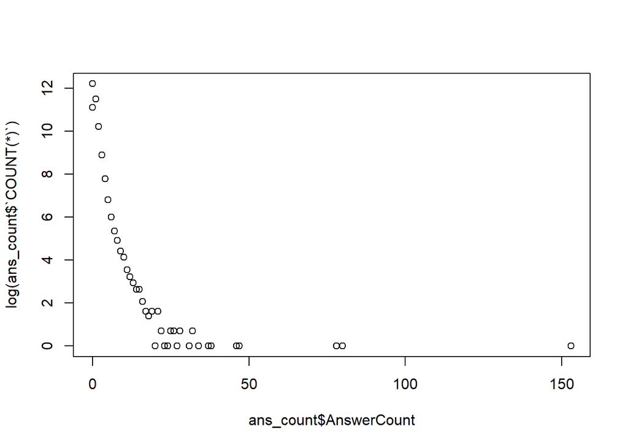

```r
plot(ans_count$AnswerCount, log(ans_count$`COUNT(*)`))
```

**QUESTION 26:** What is the length of time for a question to receive an answer? to obtaining an accepted answer? (Instructor Note: Make plots!)

I used the CreationDate here to calculate these differences.

Note that we have some negative times in Question vs Accepted Answer. I went into the database to confirm this, and it seems like there are two posts where the answer is noted before the actual post somehow (Post 129091->129077 and Post 108295->109065)

```r
#How long until accepted answer
q26a = dbGetQuery(db, 'SELECT p1.Id, p1.AcceptedAnswerId, p1.CreationDate, p2.CreationDate, (strftime("%s", p2.CreationDate) - strftime("%s", p1.CreationDate))/60 as AnsDif FROM Posts AS p1
           INNER JOIN Posts AS p2 ON p2.Id = p1.AcceptedAnswerId
           ORDER BY AnsDif;')
head(q26a)
```

```
##       Id AcceptedAnswerId            CreationDate            CreationDate
## 1 129091           129077 2014-12-14T20:27:18.950 2014-12-14T18:41:59.110
## 2 108295           109065 2014-07-17T11:36:45.187 2014-07-17T11:09:39.077
## 3  24681            24682 2012-03-15T06:59:55.263 2012-03-15T07:00:17.697
## 4  29653            29654 2012-06-01T18:18:19.507 2012-06-01T18:18:19.707
## 5  29746            29747 2012-06-03T20:55:45.227 2012-06-03T20:55:45.337
## 6  34165            34166 2012-08-12T03:36:55.910 2012-08-12T03:36:55.910
##   AnsDif
## 1   -105
## 2    -27
## 3      0
## 4      0
## 5      0
## 6      0
```

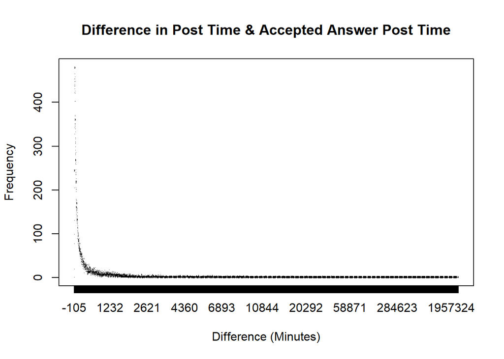

```r
q26a_table = as.data.frame(table(q26a$AnsDif))
plot(q26a_table$Var1, q26a_table$Freq, xlab = 'Difference (Minutes)', ylab = 'Frequency', main = 'Difference in Post Time & Accepted Answer Post Time')
```

Note that we have many posts here with negative post to answer times, I’m wondering if this is due to editing or something.

```r
q26p = dbGetQuery(db, 'SELECT p1.Id, p2.ParentId, p2.Id, p1.CreationDate, p2.CreationDate, (strftime("%s", p2.CreationDate) - strftime("%s", p1.CreationDate))/60 as AnsDif
          FROM Posts as p1
          INNER JOIN Posts AS p2 ON p2.ParentId = p1.Id
          WHERE p2.PostTypeId = 2
          ORDER BY AnsDif')
head(q26p)
```

```
##       Id ParentId     Id            CreationDate            CreationDate
## 1 112451   112451  45056 2014-08-19T12:46:29.950 2012-12-03T23:52:18.377
## 2 112451   112451  45091 2014-08-19T12:46:29.950 2012-12-04T13:09:31.343
## 3  16921    16921    893 2011-10-12T20:16:52.280 2010-07-28T12:48:14.233
## 4  16921    16921    894 2011-10-12T20:16:52.280 2010-07-28T12:49:31.780
## 5 116804   116804  79863 2014-09-25T21:49:50.467 2013-12-16T21:13:01.827
## 6 239431   239431 190181 2016-10-10T15:24:14.047 2016-01-11T15:19:13.797
##    AnsDif
## 1 -897894
## 2 -897096
## 3 -635488
## 4 -635487
## 5 -407556
## 6 -393125
```

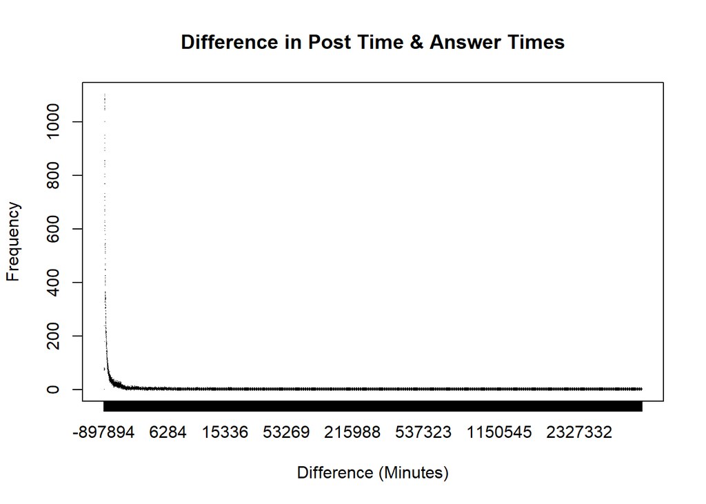

```r
q26p_table = as.data.frame(table(q26p$AnsDif))
plot(q26p_table$Var1, q26p_table$Freq, xlab = 'Difference (Minutes)', ylab = 'Frequency', main = 'Difference in Post Time & Answer Times')
```

**QUESTION 27:** How many answers are typically received before the accepted answer?

Here I used the seconds to calculate the difference, as allowing it to all be in the same unit allows for easy math. I used lots of verification using DB Browser for SQLite and comparing to the actual posts themselves.

```r
q27 = dbGetQuery(db, 'SELECT p1.Id, p2.Id AS EarlyPost, ((strftime("%s", p3.CreationDate) - strftime("%s", p2.CreationDate))/60) as Dif, COUNT(*) AS Freq
          FROM Posts as p1
          LEFT JOIN Posts AS p2 ON p1.Id = p2.ParentId
          LEFT JOIN Posts AS p3 ON p1.AcceptedAnswerId = p3.Id
          WHERE ((strftime("%s", p3.CreationDate) - strftime("%s", p2.CreationDate))/60) > 0
              GROUP BY p1.Id')

head(q27)
```

```
##   Id EarlyPost   Dif Freq
## 1  2        20    18    1
## 2  4       133     4    1
## 3  7        12     5    1
## 4 10       153 43880    2
## 5 26        41    11    2
## 6 35        38    18    1
```

```r
q27_table = as.data.frame(table(q27$Freq))
head(q27_table)
```

```
##   Var1 Freq
## 1    1 7909
## 2    2 1390
## 3    3  293
## 4    4   88
## 5    5   38
## 6    6   11
```

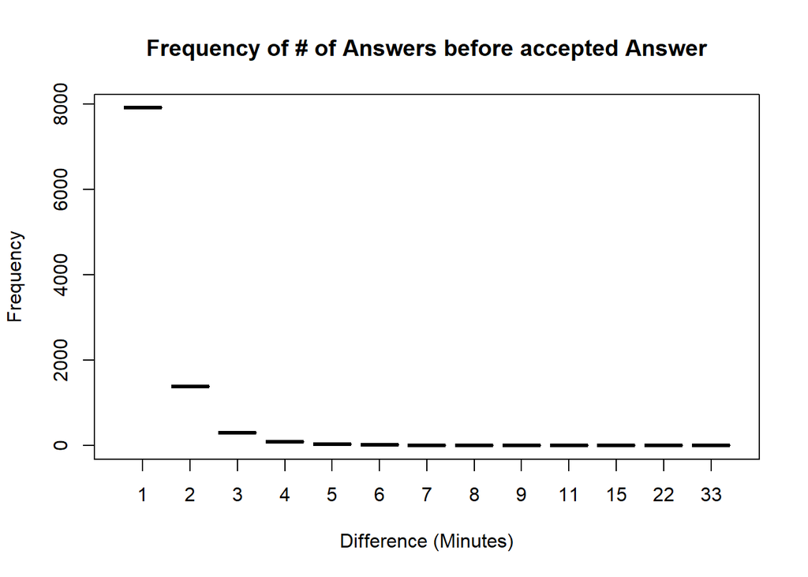

```r
plot(q27_table$Var1, q27_table$Freq, xlab = 'Difference (Minutes)', ylab = 'Frequency', main = 'Frequency of # of Answers before accepted Answer')
```

[1] https://learnsql.com/cookbook/how-to-calculate-the-difference-between-two-timestamps-in-sqlite/

[2] https://rveryday.wordpress.com/2016/11/17/create-a-cumulative-sum-column-in-r/

[3] https://www.sqlitetutorial.net/sqlite-group_concat/

[4] https://www.sqlitetutorial.net/sqlite-distinct/